NAMA : ZALZABILA RANI | NIM : 210411100082 | KELAS : METODE STATISTIKA 2D

# Exponential Smoothing

(Penghalusan Eksponensial)

**Berikut ini adalah beberapa definisi ataupun pengertian *Exponential Smoothing* (Penghalusan Eksponensial) menurut para ahli :**

- Menurut Render dan Heizer (2005), Penghalusan *exponential* adalah teknik peramalan rata-rata bergerak dengan pembobotan dimana data diberi bobot oleh sebuah fungsi *exponential*.
- Menurut Trihendradi (2005), analisis *exponential smoothing* merupakan salah satu analisis deret waktu, dan merupakan metode peramalan dengan memberi nilai pembobot pada serangkaian pengamatan sebelumnya untuk memprediksi nilai masa depan.
- Menurut T. Hani Handoko (2011), *Exponential Smoothing* adalah suatu tipe teknik peramalan rata-rata bergerak yang melakukan penimbangan terhadap data masa lalu dengan cara eksponensial sehingga data paling akhir mempunyai bobot atau timbangan lebih besar dalam rata-rata bergerak.

Metode Peramalan *Exponential Smoothing* atau Penghalusan eksponensial (Penghalusan bertingkat) ini banyak digunakan untuk meramalkan permintaan barang (demand) yang perubahannya sangat cepat.

**Cara Menghitung *Exponential Smoothing* :**

1. Menghitung koefisien α
2. Menghitung nilai peramalan periode pertama
3. Menghitung nilai peramalan di keseluruhan periode
4. Menghitung akurasi peramalan dengan peta kontrol Tracking Signal
5. Membuat grafik peta kontrol Tracking Signal

**Rumus *Exponential smoothing*:**

Ft = Ft-1+alpha((αt-1)-(ft-1))

keterangan:

Ft = nilai ramalan untuk periode ke-t

αt-1= nilai aktual periode ke t

Ft-1 = nilai ramalan untuk periode waktu yang lalu; t-1

α = konstanta pemulusan (smoothing constant)

Dengan catatan :

- Apabila data permintaan sangat bergejolak atau tidak stabil dari waktu ke waktu maka dengan memilih nilai α yang mendekati 1, seperti 0,9 atau 0,8 dst
- Apabila data permintaan relatif stabil atau tidak bergejolak dari waktu ke waktu maka dengan memilih nilai α yang mendekati 0, seperti 0,1 atau 0,2 dst
- Untuk angka pertama dalam rumus, diperoleh dari rata-rata data permintaan aktual dibagi 12 bulan Di dalam menentukan nilai α dengan cara trial dan error sesuai catatam di atas, saudara juga bisa menghitung dengan rumus α =(2/n+1)

### Contoh soal exponential smoothing sebagai berikut :

caca membuat *cookies* dan ia menjualnya secara online dengan memajang *cookies* buatannya di Tokonya. Data permintaan *cookies* pada bulan Januari 30 *cookies*, bulan Februari 51 *cookies*, bulan Maret 43 *cookies*, bulan April 66 *cookies*. bulan Mei 46 *cookies*, bulan Juni 54 *cookies*, bulan Juli 43 *cookies*, bulan Agustus 50 *cookies*, bulan September 60 *cookies*, bulan Oktober 58 *cookies*, bulan November 53 *cookies*, bulan Desember 68 *cookies*. kemudian caca memperkirakan berapa perkiraan *cookies* yang dijual pada bulan Januari 2022? Maka mari kita membantu caca dengan metode peramalan Penghalusan Exponential (exponential smoothing).

### Jawab :

Sebagaimana tahapan langkah di atas, maka yang pertama dihitung adalah menentukan koefisien α, dengan rumus α =(2/n+1), α = (2/12+1) = 1,53846 atau dibulatkan menjadi 0,2

Langkah ke 2 yakni menghitung nilai peramalan periode pertama, Cara menghitungnya yakni dengan menjumlahkan keseluruhan data permintaan kemudian dibagi dengan banyaknya periode yang ada, dimana total keseluruhan permintaan adalah 622 dibagi banyaknya periode sebanyak 12 periode sehingga, F (1) = 622/12 = 51,83

Langkah ke 3 yakni menghitung nilai peramalan di keseluruhan periode.

F2= 51,83+0,2x(30-51,83) = 47,46

F3 = 47,46 + 0,2 x (51 – 47,46) = 48,16

F4 = 48,16 + 0,2 x (43 – 48,16) = 47,12

F5 = 47,12 + 0,2 x (66 – 47,12) = 50,89

F6 = 50,89 + 0,2 x (46 – 50,89) = 49,91

F7 = 49,91 + 0,2 x (54 – 49,91) = 50,72

F8 = 50,72 + 0,2 x (43 – 50,72) = 49,17

F9 = 49,17 + 0,2 x (50 – 49,17) = 49,33

F10 = 49,33 + 0,2 x (60 – 49,33) = 51,46

F11 = 51,46 + 0,2 x (58 – 51,46) = 52,76

F12 = 52,80 + 0,2 x (53 – 52,80) = 52,80

F13 = 55,84 + 0,2 x (68 – 55,84) = 55,84

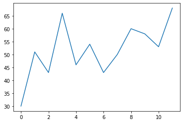

```python
#sehingga diagram yang dibentuk dari data dia atas seperti berikut :
import matplotlib.pyplot as plt
plt.plot([30,51,43,66,46,54,43,50,60,58,53,68])
```

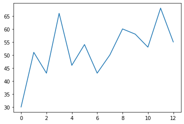

```python
#sehingga perkiraan permintaan di bukan berikutnya bisa digambarkan sebagai berikut :
import matplotlib.pyplot as plt
plt.plot([30,51,43,66,46,54,43,50,60,58,53,68,55])
```

# Moving Average

*Moving Average* adalah metode perhitungan untuk menganalisa suatu data dengan membuat serangkaian rata-rata dari sebuah kumpulan data. Model *Moving Average* disebut juga dengan model rata-rata bergerak. Model *Moving Average* bisa digunakan untuk meramalkan permintaan data, apabila data bergerak stabil dari periode ke periode selanjutnya.

**Cara Menghitung *Moving Avarage* :**

1. Mengidentifikasi pola historis dari data aktual permintaan
2. Memilih model peramalan yang sesuai dengan pola historis dari data aktual permintaan
3. Melakukan analisis data berdasarkan model peramalan yang dipilih
4. Memilih model peramalan yang tepat berdasarkan MAD (Mean Absolut Deviation) terkecil
5. Memeriksa keandalan model peramalan berdasarkan peta kontrol tracking signal

**Rumus *Moving Avarage*:**

*Moving average* (n) periode = sigma dari (permintaan dalam n - periode terdahulu) kemudian dibagi n dimana (n) adalah banyaknya periode dalam model *Moving average*, Apabila kita menggunakan *Moving average* 4 periode, maka rumus dari *Moving average* 4 periode adalah sigma dari (permintaan dalam 4 - periode terdahulu) dibagi 4

### Jawab :

**Cara perhitungan *Moving avarage* secara manual :**

Di mana di dalam Model *Moving Average* 4 bulan maka menjumlahkan selama 4 bulan berturut-turut kemudian dibagi dengan 4. Untuk Model *Moving Average* 5 bulan maka menjumlahkan selama 5 bulan kemudian dibagi dengan 5.

```python
#maka jawaban dari contoh soal di atas adalah:
#menjumlahkan permintaan 12 periode kemudian membaginya dengan 12
# (p1+p2+p3+p4+p5+p6+p7+p8+p9+p10+p11+p12)/12
print((60+75+80+88+98+100+144+155+177+190+198+218)/12)
```

[output not shown]

```
131.91666666666666
```

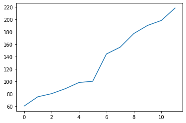

```python
#di bawah ini adalah diagram permintaan buku di tahun 2020
import matplotlib.pyplot as plt
plt.plot([60,75,80,88,98,100,144,155,177,190,198,218])
```

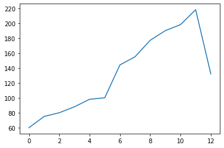

```python
#di bawah ini perkiraan diagram permintaan buku pada januari 2021
import matplotlib.pyplot as plt
plt.plot([60,75,80,88,98,100,144,155,177,190,198,218,132])
```